# we first need to recreate out RNA matrix from count files

## SLAM-seq

All SLAM-seq assays were performed at 60-70% confluency for adherent cells or 60% of the maximum cell density counted on a hemocytometer for suspension cells. 5-7h prior to each assay, growth medium was aspirated and replaced. Unless stated otherwise, cells were pre-treated with indicated small molecule inhibitors or 100µM IAA for 30 min to pre-establish full target inhibition or degradation. Newly synthesized RNA was labeled for indicated time spans (45 min or 60 min) at a final concentration of 100µM 4- thiouridine (4sU, Carbosynth). Adherent cells were harvested by direct snap-freezing of plates on dry ice. Suspension cells were spun down and immediately snap-frozen. RNA extraction was performed using the RNeasy Plus Mini Kit (Qiagen).

Total RNA was subjected to alkylation by iodoacetamide (Sigma, 10mM) for 15 min and RNA was repurified by ethanol precipitation. 500ng alkylated RNA were used as input for generating 3’-end mRNA sequencing libraries using a commercially available kit (QuantSeq 3′ mRNA-Seq Library Prep Kit FWD for Illumina and PCR Add-on Kit for Illumina, Lexogen). Deep sequencing was performed using HiSeq1500 and HiSeq2500 platforms (Illumina).

```python
names = {
"GSM2691910": "K562_MYC-AID_DMSO_rep-1",
"GSM2691911": "K562_MYC-AID_DMSO_rep-2",
"GSM2691912": "K562_MYC-AID_DMSO_rep-3",
"GSM2691913": "K562_MYC-AID_IAA_rep-1",
"GSM2691914": "K562_MYC-AID_IAA_rep-2",
"GSM2691915": "K562_MYC-AID_IAA_rep-3",
"GSM2691916": "HCT116_MYC-AID_DMSO_rep-1",
"GSM2691917": "HCT116_MYC-AID_DMSO_rep-2",
"GSM2691918": "HCT116_MYC-AID_DMSO_rep-3",
"GSM2691919": "HCT116_MYC-AID_IAA_rep-1",
"GSM2691920": "HCT116_MYC-AID_IAA_rep-2",
"GSM2691921": "HCT116_MYC-AID_IAA_rep-3"
}
```

```python
tccounts = tccounts.rename(columns=names)
readcounts = readcounts.rename(columns=names)
readcounts
```

|  | K562_MYC-AID_DMSO_rep-1 | K562_MYC-AID_DMSO_rep-2 | K562_MYC-AID_DMSO_rep-3 | K562_MYC-AID_IAA_rep-1 | K562_MYC-AID_IAA_rep-2 | K562_MYC-AID_IAA_rep-3 | HCT116_MYC-AID_DMSO_rep-1 | HCT116_MYC-AID_DMSO_rep-2 | HCT116_MYC-AID_DMSO_rep-3 | HCT116_MYC-AID_IAA_rep-1 | HCT116_MYC-AID_IAA_rep-2 | HCT116_MYC-AID_IAA_rep-3 |
| --- | --- | --- | --- | --- | --- | --- | --- | --- | --- | --- | --- | --- |
| A1BG | 55 | 98 | 79 | 79 | 68 | 73 | 0 | 0 | 0 | 2 | 2 | 0 |
| NAT1 | 397 | 465 | 390 | 433 | 470 | 431 | 186 | 178 | 152 | 150 | 159 | 140 |
| AADAC | 0 | 0 | 0 | 0 | 2 | 0 | 35 | 38 | 31 | 35 | 43 | 48 |
| AAMP | 5637 | 6368 | 5238 | 5788 | 6363 | 6952 | 5897 | 7185 | 6030 | 8749 | 6800 | 7211 |
| AARS1 | 2620 | 2935 | 2395 | 2584 | 2752 | 2897 | 2705 | 3122 | 2802 | 3512 | 3104 | 3149 |
| ABAT | 2 | 4 | 1 | 1 | 7 | 4 | 51 | 53 | 51 | 54 | 43 | 58 |
| ABCA2 | 74 | 67 | 95 | 63 | 75 | 81 | 267 | 297 | 243 | 298 | 274 | 253 |
| ABCA3 | 289 | 284 | 244 | 236 | 264 | 250 | 36 | 24 | 20 | 28 | 28 | 25 |
| ABCB7 | 598 | 590 | 523 | 556 | 574 | 616 | 544 | 601 | 532 | 599 | 517 | 560 |
| ABCF1 | 4687 | 4960 | 4518 | 4829 | 4834 | 5082 | 2059 | 2180 | 2009 | 2333 | 1990 | 1982 |
| ABL1 | 3949 | 4525 | 3703 | 4198 | 4908 | 5007 | 1020 | 1017 | 940 | 1340 | 1013 | 968 |
| ABL2 | 1535 | 1531 | 1357 | 1364 | 1562 | 1579 | 761 | 865 | 803 | 833 | 871 | 757 |
| ABR | 3 | 1 | 3 | 3 | 2 | 2 | 659 | 748 | 687 | 692 | 765 | 601 |
| ACAA1 | 1242 | 1136 | 1088 | 1055 | 1067 | 1081 | 814 | 996 | 895 | 793 | 783 | 775 |
| ACACA | 1391 | 1514 | 1346 | 1445 | 1525 | 1588 | 871 | 875 | 848 | 781 | 804 | 709 |
| ACACB | 6 | 3 | 2 | 7 | 5 | 1 | 99 | 104 | 93 | 115 | 82 | 128 |
| ACADM | 3270 | 3856 | 3173 | 3202 | 3332 | 3544 | 1339 | 1451 | 1511 | 1319 | 1269 | 1216 |
| ACADS | 687 | 653 | 639 | 662 | 705 | 807 | 334 | 406 | 345 | 552 | 401 | 480 |
| ACADSB | 530 | 606 | 510 | 521 | 629 | 669 | 1055 | 1069 | 939 | 1005 | 991 | 854 |
| ACADVL | 1665 | 1701 | 1470 | 1682 | 1542 | 1701 | 2555 | 2862 | 2555 | 2579 | 2484 | 2253 |
| ACAT1 | 4821 | 5219 | 4503 | 4616 | 5190 | 4981 | 1847 | 2111 | 1978 | 2334 | 2017 | 2079 |
| ACAT2 | 3743 | 4222 | 3609 | 3834 | 4012 | 4370 | 1098 | 1419 | 1168 | 1477 | 1317 | 1322 |
| ASIC1 | 259 | 265 | 231 | 214 | 257 | 275 | 368 | 454 | 403 | 443 | 416 | 443 |
| ACHE | 175 | 188 | 170 | 167 | 209 | 219 | 21 | 21 | 23 | 23 | 16 | 22 |
| ACLY | 5158 | 5561 | 4751 | 4693 | 4833 | 4912 | 6036 | 6376 | 5756 | 6214 | 5628 | 5692 |
| ACO1 | 1595 | 1720 | 1543 | 1564 | 1828 | 1876 | 1048 | 1216 | 963 | 1427 | 1181 | 1132 |
| ACR | 0 | 0 | 0 | 0 | 0 | 0 | 7 | 10 | 5 | 8 | 9 | 4 |
| ACO2 | 3280 | 3571 | 2928 | 3424 | 3510 | 3927 | 2971 | 3521 | 2915 | 4581 | 3576 | 3762 |
| ACOX1 | 1220 | 1260 | 1190 | 1108 | 1142 | 1244 | 1320 | 1442 | 1395 | 1376 | 1319 | 1260 |
| ACP1 | 8793 | 9725 | 8399 | 8383 | 9417 | 8946 | 5379 | 6196 | 5116 | 5189 | 5269 | 4950 |
| ... | ... | ... | ... | ... | ... | ... | ... | ... | ... | ... | ... | ... |
| CLCA4-AS1 | 21 | 13 | 2 | 7 | 13 | 14 | 6 | 4 | 6 | 8 | 10 | 8 |
| LINC02609 | 484 | 461 | 396 | 456 | 440 | 433 | 88 | 89 | 84 | 93 | 96 | 87 |
| 105379252 | 95 | 78 | 65 | 82 | 75 | 81 | 25 | 20 | 15 | 32 | 18 | 16 |
| 105447645 | 2 | 4 | 3 | 4 | 2 | 1 | 24 | 28 | 31 | 47 | 36 | 30 |
| B3GALT1-AS1 | 237 | 213 | 187 | 196 | 211 | 193 | 2 | 2 | 2 | 1 | 5 | 0 |
| MIR34AHG | 0 | 1 | 1 | 1 | 1 | 1 | 55 | 69 | 74 | 87 | 55 | 51 |
| SNORD143 | 16 | 25 | 13 | 16 | 14 | 19 | 25 | 18 | 27 | 31 | 27 | 17 |
| SNORD144 | 4 | 9 | 11 | 8 | 11 | 1 | 9 | 11 | 12 | 4 | 10 | 7 |
| SCARNA26A | 6 | 1 | 3 | 5 | 1 | 1 | 22 | 32 | 31 | 36 | 33 | 37 |
| SNORA86 | 4 | 6 | 0 | 9 | 3 | 6 | 7 | 10 | 7 | 11 | 8 | 14 |
| SNORA100 | 1354 | 1383 | 1267 | 1157 | 1486 | 1341 | 2561 | 2784 | 2510 | 3006 | 2596 | 2577 |
| SNORA103 | 13 | 17 | 12 | 18 | 23 | 20 | 13 | 14 | 11 | 14 | 10 | 14 |
| SNORA105A | 4948 | 5415 | 4656 | 4524 | 4467 | 4205 | 8695 | 9518 | 8296 | 9541 | 8578 | 8727 |
| SNORA105B | 4948 | 5415 | 4656 | 4524 | 4467 | 4205 | 8695 | 9518 | 8296 | 9541 | 8578 | 8727 |
| SNORA109 | 145 | 128 | 177 | 130 | 132 | 132 | 264 | 295 | 327 | 199 | 213 | 170 |
| SNORD132 | 12 | 14 | 20 | 16 | 15 | 11 | 3 | 12 | 11 | 10 | 9 | 4 |
| SNORD137 | 229 | 220 | 245 | 222 | 250 | 221 | 478 | 489 | 374 | 302 | 305 | 287 |
| SNORD140 | 20 | 33 | 19 | 21 | 24 | 27 | 29 | 28 | 25 | 41 | 27 | 26 |
| SNORD141A | 142 | 189 | 99 | 103 | 156 | 112 | 97 | 112 | 54 | 131 | 70 | 115 |
| SNORD141B | 142 | 189 | 99 | 103 | 156 | 112 | 97 | 112 | 54 | 131 | 70 | 115 |
| LINC00680 | 367 | 379 | 337 | 289 | 334 | 350 | 53 | 52 | 79 | 68 | 47 | 58 |
| 106660613 | 5 | 10 | 8 | 6 | 8 | 2 | 4 | 3 | 5 | 7 | 1 | 1 |
| 106707243 | 78 | 81 | 61 | 72 | 67 | 72 | 50 | 66 | 50 | 47 | 78 | 42 |
| PCF11-AS1 | 41 | 44 | 39 | 37 | 43 | 28 | 30 | 39 | 45 | 27 | 31 | 28 |
| BUB1B-PAK6 | 84 | 102 | 70 | 95 | 88 | 87 | 434 | 459 | 436 | 463 | 444 | 419 |
| 106865373 | 42 | 60 | 42 | 43 | 42 | 52 | 75 | 97 | 69 | 71 | 64 | 77 |
| 107080638 | 697 | 779 | 595 | 677 | 722 | 732 | 121 | 153 | 133 | 175 | 162 | 168 |
| BOLA2-SMG1P6 | 81 | 84 | 72 | 89 | 61 | 57 | 76 | 73 | 54 | 87 | 80 | 83 |
| 107303344 | 0 | 0 | 0 | 0 | 0 | 0 | 162 | 167 | 178 | 164 | 152 | 171 |
| SCARNA18B | 42 | 29 | 40 | 34 | 26 | 33 | 31 | 14 | 29 | 29 | 21 | 25 |

14553 rows × 12 columns

```python
tccounts.to_csv("../data/MYC slamseq paper/tccounts.csv")
readcounts.to_csv("../data/MYC slamseq paper/readcounts.csv")
```

```python
mtccounts = pd.DataFrame()
mreadcounts = pd.DataFrame()
for i in range(4):
    mtccounts[tccounts.columns[i*3].split("_rep")[0]] = tccounts[tccounts.columns[(i*3):(i*3)+3]].mean(1)
    mreadcounts[tccounts.columns[i*3].split("_rep")[0]] = readcounts[readcounts.columns[(i*3):(i*3)+3]].mean(1)
```

```python
mtccounts.to_csv("../data/MYC slamseq paper/mean_tccounts.csv")
mreadcounts.to_csv("../data/MYC slamseq paper/mean_readcounts.csv")
```

```python
mtccounts = pd.DataFrame()
mreadcounts = pd.DataFrame()
for i in range(4):
    mtccounts[tccounts.columns[i*3].split("_rep")[0]] = tccounts[tccounts.columns[(i*3):(i*3)+3]].median(1)
    mreadcounts[tccounts.columns[i*3].split("_rep")[0]] = readcounts[readcounts.columns[(i*3):(i*3)+3]].median(1)
```

```python
mtccounts.to_csv("../data/MYC slamseq paper/median_tccounts.csv")
mreadcounts.to_csv("../data/MYC slamseq paper/median_readcounts.csv")
```

```python
(tccounts/readcounts).fillna(0).to_csv("../data/MYC slamseq paper/median_readcounts.csv")
```

# lets look at the similarity accross replicates

we have some outliers, else it seems to make some sense and on average, to be extremelly similar!

```python
readcounts.loc['MYC']
```

```
K562_MYC-AID_DMSO_rep-1      3435
K562_MYC-AID_DMSO_rep-2      3627
K562_MYC-AID_DMSO_rep-3      3085
K562_MYC-AID_IAA_rep-1       4012
K562_MYC-AID_IAA_rep-2       4522
K562_MYC-AID_IAA_rep-3       4151
HCT116_MYC-AID_DMSO_rep-1    5870
HCT116_MYC-AID_DMSO_rep-2    5812
HCT116_MYC-AID_DMSO_rep-3    5792
HCT116_MYC-AID_IAA_rep-1     6881
HCT116_MYC-AID_IAA_rep-2     6201
HCT116_MYC-AID_IAA_rep-3     6138
Name: MYC, dtype: int64
```

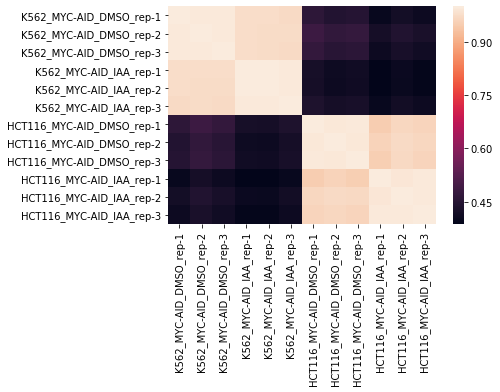

```python
%matplotlib inline
sns.heatmap(tccounts.corr(),
            xticklabels=tccounts.columns,
            yticklabels=tccounts.columns)
```

```python
scatter(UMAP(n_neighbors=2,min_dist=0.1).fit_transform(tccounts.values.T),labels=tccounts.columns, radi=1)
```

[interactive chart not shown]

very strangely, we have in non euclidean space a structure that matches the labels we have. We hypotesized that noise might explain the difference in correlation that we see, however it would not explain that in euclidean space, things cluster still very well but differently.

As a matter of fact. real noise would not change the correlation at all. This noise has a structure. One thing can explain read count that, at low frequency transcripts, especially create a specific pattern: contamination

```python
tccounts.columns = [i.replace('-','.') for i in tccounts.columns]
readcounts.columns = [i.replace('-','.') for i in readcounts.columns]
```

```python
readcounts
```

|  | K562_MYC.AID_DMSO_rep.1 | K562_MYC.AID_DMSO_rep.2 | K562_MYC.AID_DMSO_rep.3 | K562_MYC.AID_IAA_rep.1 | K562_MYC.AID_IAA_rep.2 | K562_MYC.AID_IAA_rep.3 | HCT116_MYC.AID_DMSO_rep.1 | HCT116_MYC.AID_DMSO_rep.2 | HCT116_MYC.AID_DMSO_rep.3 | HCT116_MYC.AID_IAA_rep.1 | HCT116_MYC.AID_IAA_rep.2 | HCT116_MYC.AID_IAA_rep.3 |
| --- | --- | --- | --- | --- | --- | --- | --- | --- | --- | --- | --- | --- |
| A1BG | 55 | 98 | 79 | 79 | 68 | 73 | 0 | 0 | 0 | 2 | 2 | 0 |
| NAT1 | 397 | 465 | 390 | 433 | 470 | 431 | 186 | 178 | 152 | 150 | 159 | 140 |
| AADAC | 0 | 0 | 0 | 0 | 2 | 0 | 35 | 38 | 31 | 35 | 43 | 48 |
| AAMP | 5637 | 6368 | 5238 | 5788 | 6363 | 6952 | 5897 | 7185 | 6030 | 8749 | 6800 | 7211 |
| AARS1 | 2620 | 2935 | 2395 | 2584 | 2752 | 2897 | 2705 | 3122 | 2802 | 3512 | 3104 | 3149 |
| ABAT | 2 | 4 | 1 | 1 | 7 | 4 | 51 | 53 | 51 | 54 | 43 | 58 |
| ABCA2 | 74 | 67 | 95 | 63 | 75 | 81 | 267 | 297 | 243 | 298 | 274 | 253 |
| ABCA3 | 289 | 284 | 244 | 236 | 264 | 250 | 36 | 24 | 20 | 28 | 28 | 25 |
| ABCB7 | 598 | 590 | 523 | 556 | 574 | 616 | 544 | 601 | 532 | 599 | 517 | 560 |
| ABCF1 | 4687 | 4960 | 4518 | 4829 | 4834 | 5082 | 2059 | 2180 | 2009 | 2333 | 1990 | 1982 |
| ABL1 | 3949 | 4525 | 3703 | 4198 | 4908 | 5007 | 1020 | 1017 | 940 | 1340 | 1013 | 968 |
| ABL2 | 1535 | 1531 | 1357 | 1364 | 1562 | 1579 | 761 | 865 | 803 | 833 | 871 | 757 |
| ABR | 3 | 1 | 3 | 3 | 2 | 2 | 659 | 748 | 687 | 692 | 765 | 601 |
| ACAA1 | 1242 | 1136 | 1088 | 1055 | 1067 | 1081 | 814 | 996 | 895 | 793 | 783 | 775 |
| ACACA | 1391 | 1514 | 1346 | 1445 | 1525 | 1588 | 871 | 875 | 848 | 781 | 804 | 709 |
| ACACB | 6 | 3 | 2 | 7 | 5 | 1 | 99 | 104 | 93 | 115 | 82 | 128 |
| ACADM | 3270 | 3856 | 3173 | 3202 | 3332 | 3544 | 1339 | 1451 | 1511 | 1319 | 1269 | 1216 |
| ACADS | 687 | 653 | 639 | 662 | 705 | 807 | 334 | 406 | 345 | 552 | 401 | 480 |
| ACADSB | 530 | 606 | 510 | 521 | 629 | 669 | 1055 | 1069 | 939 | 1005 | 991 | 854 |
| ACADVL | 1665 | 1701 | 1470 | 1682 | 1542 | 1701 | 2555 | 2862 | 2555 | 2579 | 2484 | 2253 |
| ACAT1 | 4821 | 5219 | 4503 | 4616 | 5190 | 4981 | 1847 | 2111 | 1978 | 2334 | 2017 | 2079 |
| ACAT2 | 3743 | 4222 | 3609 | 3834 | 4012 | 4370 | 1098 | 1419 | 1168 | 1477 | 1317 | 1322 |
| ASIC1 | 259 | 265 | 231 | 214 | 257 | 275 | 368 | 454 | 403 | 443 | 416 | 443 |
| ACHE | 175 | 188 | 170 | 167 | 209 | 219 | 21 | 21 | 23 | 23 | 16 | 22 |
| ACLY | 5158 | 5561 | 4751 | 4693 | 4833 | 4912 | 6036 | 6376 | 5756 | 6214 | 5628 | 5692 |
| ACO1 | 1595 | 1720 | 1543 | 1564 | 1828 | 1876 | 1048 | 1216 | 963 | 1427 | 1181 | 1132 |
| ACR | 0 | 0 | 0 | 0 | 0 | 0 | 7 | 10 | 5 | 8 | 9 | 4 |
| ACO2 | 3280 | 3571 | 2928 | 3424 | 3510 | 3927 | 2971 | 3521 | 2915 | 4581 | 3576 | 3762 |
| ACOX1 | 1220 | 1260 | 1190 | 1108 | 1142 | 1244 | 1320 | 1442 | 1395 | 1376 | 1319 | 1260 |
| ACP1 | 8793 | 9725 | 8399 | 8383 | 9417 | 8946 | 5379 | 6196 | 5116 | 5189 | 5269 | 4950 |
| ... | ... | ... | ... | ... | ... | ... | ... | ... | ... | ... | ... | ... |
| CLCA4-AS1 | 21 | 13 | 2 | 7 | 13 | 14 | 6 | 4 | 6 | 8 | 10 | 8 |
| LINC02609 | 484 | 461 | 396 | 456 | 440 | 433 | 88 | 89 | 84 | 93 | 96 | 87 |
| 105379252 | 95 | 78 | 65 | 82 | 75 | 81 | 25 | 20 | 15 | 32 | 18 | 16 |
| 105447645 | 2 | 4 | 3 | 4 | 2 | 1 | 24 | 28 | 31 | 47 | 36 | 30 |
| B3GALT1-AS1 | 237 | 213 | 187 | 196 | 211 | 193 | 2 | 2 | 2 | 1 | 5 | 0 |
| MIR34AHG | 0 | 1 | 1 | 1 | 1 | 1 | 55 | 69 | 74 | 87 | 55 | 51 |
| SNORD143 | 16 | 25 | 13 | 16 | 14 | 19 | 25 | 18 | 27 | 31 | 27 | 17 |
| SNORD144 | 4 | 9 | 11 | 8 | 11 | 1 | 9 | 11 | 12 | 4 | 10 | 7 |
| SCARNA26A | 6 | 1 | 3 | 5 | 1 | 1 | 22 | 32 | 31 | 36 | 33 | 37 |
| SNORA86 | 4 | 6 | 0 | 9 | 3 | 6 | 7 | 10 | 7 | 11 | 8 | 14 |
| SNORA100 | 1354 | 1383 | 1267 | 1157 | 1486 | 1341 | 2561 | 2784 | 2510 | 3006 | 2596 | 2577 |
| SNORA103 | 13 | 17 | 12 | 18 | 23 | 20 | 13 | 14 | 11 | 14 | 10 | 14 |
| SNORA105A | 4948 | 5415 | 4656 | 4524 | 4467 | 4205 | 8695 | 9518 | 8296 | 9541 | 8578 | 8727 |
| SNORA105B | 4948 | 5415 | 4656 | 4524 | 4467 | 4205 | 8695 | 9518 | 8296 | 9541 | 8578 | 8727 |
| SNORA109 | 145 | 128 | 177 | 130 | 132 | 132 | 264 | 295 | 327 | 199 | 213 | 170 |
| SNORD132 | 12 | 14 | 20 | 16 | 15 | 11 | 3 | 12 | 11 | 10 | 9 | 4 |
| SNORD137 | 229 | 220 | 245 | 222 | 250 | 221 | 478 | 489 | 374 | 302 | 305 | 287 |
| SNORD140 | 20 | 33 | 19 | 21 | 24 | 27 | 29 | 28 | 25 | 41 | 27 | 26 |
| SNORD141A | 142 | 189 | 99 | 103 | 156 | 112 | 97 | 112 | 54 | 131 | 70 | 115 |
| SNORD141B | 142 | 189 | 99 | 103 | 156 | 112 | 97 | 112 | 54 | 131 | 70 | 115 |
| LINC00680 | 367 | 379 | 337 | 289 | 334 | 350 | 53 | 52 | 79 | 68 | 47 | 58 |
| 106660613 | 5 | 10 | 8 | 6 | 8 | 2 | 4 | 3 | 5 | 7 | 1 | 1 |
| 106707243 | 78 | 81 | 61 | 72 | 67 | 72 | 50 | 66 | 50 | 47 | 78 | 42 |
| PCF11-AS1 | 41 | 44 | 39 | 37 | 43 | 28 | 30 | 39 | 45 | 27 | 31 | 28 |
| BUB1B-PAK6 | 84 | 102 | 70 | 95 | 88 | 87 | 434 | 459 | 436 | 463 | 444 | 419 |
| 106865373 | 42 | 60 | 42 | 43 | 42 | 52 | 75 | 97 | 69 | 71 | 64 | 77 |
| 107080638 | 697 | 779 | 595 | 677 | 722 | 732 | 121 | 153 | 133 | 175 | 162 | 168 |
| BOLA2-SMG1P6 | 81 | 84 | 72 | 89 | 61 | 57 | 76 | 73 | 54 | 87 | 80 | 83 |
| 107303344 | 0 | 0 | 0 | 0 | 0 | 0 | 162 | 167 | 178 | 164 | 152 | 171 |
| SCARNA18B | 42 | 29 | 40 | 34 | 26 | 33 | 31 | 14 | 29 | 29 | 21 | 25 |

14553 rows × 12 columns

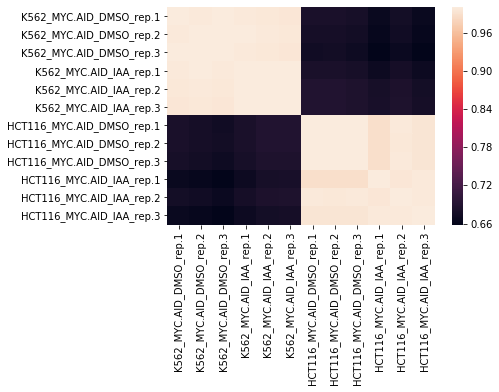

```python
%matplotlib inline
sns.heatmap(readcounts.corr(),
            xticklabels=readcounts.columns,
            yticklabels=readcounts.columns)
```

## Getting the Core TF information

```python
ctf=pd.read_csv('../data/CTF.csv',header=None)[0].values.tolist()
ctf
```

```
['MYC',
 'MYB',
 'SPI1',
 'RUNX1',
 'GSE1',
 'IRF2BP2',
 'FLI1',
 'ELF2',
 'ZEB2',
 'IKAROS',
 'GFI1',
 'LMO2',
 'CEBPA',
 'MEF2D',
 'MEF2C',
 'IRF8',
 'MEIS1',
 'RUNX2',
 'ETV6',
 'LDB1',
 'RUNX2',
 'SP1',
 'ZMYND8']
```

```python
set(ctf) & set(tccounts.index)
```

```
{'CEBPA',
 'ELF2',
 'ETV6',
 'GFI1',
 'GSE1',
 'IRF2BP2',
 'LDB1',
 'LMO2',
 'MEF2C',
 'MEF2D',
 'MEIS1',
 'MYB',
 'MYC',
 'RUNX1',
 'RUNX2',
 'SP1',
 'SPI1',
 'ZEB2',
 'ZMYND8'}
```

```python
ctfpos = [val for val in tccounts.index if val in ctf]
notctfpos = [val for val in tccounts.index if val not in ctf]
```

```python
ctfpos.extend(['EGR1','SERTAD1'])
```

# Let's look at how they change accross time

## DESEQ ANALYSIS

```python
readcounts["genes"] = readcounts.index
readcounts = readcounts.reset_index(drop=True)
tccounts["genes"] = tccounts.index
tccounts = tccounts.reset_index(drop=True)
```

```python
tccounts.iloc[140]
```

```
K562_MYC.AID_DMSO_rep.1        126
K562_MYC.AID_DMSO_rep.2         89
K562_MYC.AID_DMSO_rep.3        104
K562_MYC.AID_IAA_rep.1          95
K562_MYC.AID_IAA_rep.2          97
K562_MYC.AID_IAA_rep.3         110
HCT116_MYC.AID_DMSO_rep.1       83
HCT116_MYC.AID_DMSO_rep.2       87
HCT116_MYC.AID_DMSO_rep.3       76
HCT116_MYC.AID_IAA_rep.1        82
HCT116_MYC.AID_IAA_rep.2        83
HCT116_MYC.AID_IAA_rep.3        90
genes                        ANXA7
Name: 140, dtype: object
```

```python
tccounts.columns
```

```
Index(['K562_MYC.AID_DMSO_rep.1', 'K562_MYC.AID_DMSO_rep.2',
       'K562_MYC.AID_DMSO_rep.3', 'K562_MYC.AID_IAA_rep.1',
       'K562_MYC.AID_IAA_rep.2', 'K562_MYC.AID_IAA_rep.3',
       'HCT116_MYC.AID_DMSO_rep.1', 'HCT116_MYC.AID_DMSO_rep.2',
       'HCT116_MYC.AID_DMSO_rep.3', 'HCT116_MYC.AID_IAA_rep.1',
       'HCT116_MYC.AID_IAA_rep.2', 'HCT116_MYC.AID_IAA_rep.3', 'genes'],
      dtype='object')
```

```python
design_K562 = pd.DataFrame(index=[i.replace('-','.') for i in tccounts.columns.values[:-1]],
                      columns=['DMSO','VHL'],
                      data=np.array([[1,1,1,0,0,0,0,0,0,0,0,0],
                                     [0,0,0,1,1,1,0,0,0,0,0,0]],dtype=bool).T)
```

```python
design_HCT116 = pd.DataFrame(index=[i.replace('-','.') for i in tccounts.columns.values[:-1]],
                      columns=['DMSO','VHL'],
                      data=np.array([[0,0,0,0,0,0,1,1,1,0,0,0],
                                     [0,0,0,0,0,0,0,0,0,1,1,1]],dtype=bool).T)
```

```python
design_K562
```

|  | DMSO | VHL |
| --- | --- | --- |
| K562_MYC.AID_DMSO_rep.1 | True | False |
| K562_MYC.AID_DMSO_rep.2 | True | False |
| K562_MYC.AID_DMSO_rep.3 | True | False |
| K562_MYC.AID_IAA_rep.1 | False | True |
| K562_MYC.AID_IAA_rep.2 | False | True |
| K562_MYC.AID_IAA_rep.3 | False | True |
| HCT116_MYC.AID_DMSO_rep.1 | False | False |
| HCT116_MYC.AID_DMSO_rep.2 | False | False |
| HCT116_MYC.AID_DMSO_rep.3 | False | False |
| HCT116_MYC.AID_IAA_rep.1 | False | False |
| HCT116_MYC.AID_IAA_rep.2 | False | False |
| HCT116_MYC.AID_IAA_rep.3 | False | False |

# Differential gene expression analysis, PCA and GO-term enrichment

For gene-level analysis, raw reads mapped to different UTR annotations of the same gene were summed up by Entrez Gene ID. Pilot studies of K562 cells with kinase inhibitors were performed as single experiments.

Analysis of differential gene expression was restricted to genes with ≥ 10 reads in at least one condition for 50bp sequencing runs (flavopiridol and DMSO) or ≥ 20 reads in at least one condition for 100bp sequencing runs (mk2206, trametinib, nilotinib, trametinib + mk2206 and DMSO). For estimating differential expression, a pseudo-count of 1 raw read was added to all genes.

#### All other SLAM-seq experiments were performed in triplicates and analyzed as follows.

Differential gene expression calling was performed on raw read counts with ≥ 2 T>C conversions using DESeq2 (version 1.14.1) with default settings, and with size factors estimated on corresponding total mRNA reads for global normalization.

Downstream analysis was restricted to genes passing all internal filters for FDR estimation by DESeq2. Principal component analysis was performed after variance stabilizing transformation on the 500 most variable genes across all conditions of a given experiment. GO-term enrichment analysis was performed on genes significantly and strongly downregulated (FDR ≤ 0.1, log2FC ≤ -1) in SLAM-seq upon IAA-treatment in K562MYC-AID + Tir1 by the PANTHER Overrepresentation Test (Fisher's Exact with FDR multiple test correction, release 20171205, http://pantherdb.org) on GO Ontology database Released 2017-12-27.

```python
deseq_K562 = pyDESeq2.pyDESeq2(count_matrix=tccounts[tccounts.columns[np.array([1,1,1,1,1,1,0,0,0,0,0,0,1],np.bool)]],
                         design_matrix=design_K562[np.array([1,1,1,1,1,1,0,0,0,0,0,0],np.bool)],
                         design_formula="~DMSO - VHL",
                         gene_column="genes")
```

```
3.0.4
```

```python
deseq_HCT116 = pyDESeq2.pyDESeq2(count_matrix=tccounts[tccounts.columns[np.array([0,0,0,0,0,0,1,1,1,1,1,1,1],np.bool)]],
                         design_matrix=design_HCT116[np.array([0,0,0,0,0,0,1,1,1,1,1,1],np.bool)],
                         design_formula="~DMSO - VHL",
                         gene_column="genes")
```

```
3.0.4
```

```python
scaling2 = np.log2((tccounts.mean()/readcounts.mean())[[0,1]].mean() / (tccounts.mean()/readcounts.mean())[4:7].mean())
scaling2
```

```
-0.19444121489296778
```

```python
scaling6 = np.log2((tccounts.mean()/readcounts.mean())[[2,3]].mean() / (tccounts.mean()/readcounts.mean())[7:11].mean())
scaling6
```

```
0.2677929313460023
```

```python
(readcounts[readcounts.columns[
        np.array([1,1,1,1,1,1,0,0,0,0,0,0,0],np.bool)]].values+1).sum(1)
```

```
array([ 458, 2592,    8, ...,  450,    6,  210])
```

```python
deseq_K562.run_estimate_size_factors(normMatrix = (readcounts[readcounts.columns[
        np.array([1,1,1,1,1,1,0,0,0,0,0,0,0],np.bool)]].values+1))
deseq_HCT116.run_estimate_size_factors(normMatrix = (readcounts[readcounts.columns[
        np.array([0,0,0,0,0,0,1,1,1,1,1,1,0],np.bool)]].values+1))
```

```
R[write to console]: using 'normMatrix', adding normalization factors which correct for library size

R[write to console]: using 'normMatrix', adding normalization factors which correct for library size
```

```python
deseq_K562.run_deseq()
deseq_HCT116.run_deseq()
```

[output not shown]

```python
deseq_K562.get_deseq_result()
deseq_HCT116.get_deseq_result()
```

```python
res_K562 = deseq_K562.deseq_result
res_HCT116 = deseq_HCT116.deseq_result
```

```python
res_K562.pvalue = np.nan_to_num(np.array(res_K562.pvalue), 1)
res_K562.log2FoldChange = np.nan_to_num(np.array(res_K562.log2FoldChange), 0)
res_HCT116.pvalue = np.nan_to_num(np.array(res_HCT116.pvalue), 1)
res_HCT116.log2FoldChange = np.nan_to_num(np.array(res_HCT116.log2FoldChange), 0)
```

```python
res_K562.log2FoldChange = -res_K562.log2FoldChange
res_HCT116.log2FoldChange = -res_HCT116.log2FoldChange
```

```python
res_K562["gene_id"] = res_K562.genes
res_HCT116["gene_id"] = res_HCT116.genes
```

```python
res6.log2FoldChange = res6.log2FoldChange - scaling6
```

```python
res_K562.to_csv('../data/MYC slamseq paper/K562_diffexp.csv')
```

```python
show(volcano(res_K562,tohighlight=ctf, searchbox=True, maxvalue=20,minpval=3, minlogfold=0.4))
```

```
0.05109329888883603 0.8890101125168898
0.11667745551623075 0.7644032845236838
```

[interactive chart not shown]

```python
res_HCT116.to_csv('../data/MYC slamseq paper/HCT116_diffexp.csv')
```

```python
show(volcano(res_HCT116,tohighlight=ctf, searchbox=True, minpval=4, minlogfold=0.3))
```

```
0.028853276599796945 0.935721747902118
0.10400436408579962 0.7870378809644093
```

[interactive chart not shown]

we can conclude that we get similar results to the slamseq myc paper although it seems that our values are a bit skewed toward higher expression than what is on the slamseq paper. It mightt be explained by the pseudo count of 1 that I did not set. Because I think it would highly bias the DESeq algorithm.